# HW5_Modeling_KoleCounts

ʻAʻaliʻi Kelling

2025-02-20

## **Homework 5 - Modeling Kole Counts**

# **Instructions**

In this assignment we will again analyze NOAA reef fish survey data. The goal is to learn how to model count data, and to get a sense for the challenges in trying to deduce processes from observed patterns.

Imagine that we are interested in the habitat characteristics that favor Ctenochaetus strigosus, known as kole in Hawaiian, and with the English common name spotted surgeonfish in this dataset.

We will focus on the role of different types of benthic substrate, and the most common substrate types in this dataset are: - turf algae (column ‘ta’), - hard coral (column ‘hard_coral’), - sand (column ‘sand’), and - crustose coralline algae (column ‘cca’).

I have included a dataset that only includes this species, and only the sampling period during which turf algae percent cover was measured.

## Loading datasets

```
##
## arm (Version 1.14-4, built: 2024-4-1)
```

```
## Working directory is /Users/aaliikelling/Desktop/Git Hub Repositories/OCN683/HW5
```

```
##
##
## here() starts at /Users/aaliikelling/Desktop/Git Hub Repositories/OCN683
##
##
```

```
## Caution: You lose important information if you filter this package's results.
## See '? untidy'
##
##
##
```

```
## 'data.frame':    310 obs. of  47 variables:
##  $ taxonname          : chr  "Ctenochaetus strigosus" "Ctenochaetus strigosus" "Ctenochaetus strigosus" "Ctenochaetus strigosus" ...
##  $ replicateid        : int  1845958526 1845958527 1845958528 1845958529 1845958530 1845958531 1845958532 1845958533 1845958534 1845958535 ...
##  $ count              : int  0 0 0 0 0 1 5 0 0 0 ...
##  $ time               : chr  "2013-08-03T00:00:00Z" "2013-08-03T00:00:00Z" "2013-08-03T00:00:00Z" "2013-08-03T00:00:00Z" ...
##  $ latitude           : num  20.2 20.2 20.2 20.2 20.3 ...
##  $ longitude          : num  -156 -156 -156 -156 -156 ...
##  $ region_name        : chr  "Main Hawaiian Islands" "Main Hawaiian Islands" "Main Hawaiian Islands" "Main Hawaiian Islands" ...
##  $ island             : chr  "Hawaii" "Hawaii" "Hawaii" "Hawaii" ...
##  $ site               : chr  "HAW-468" "HAW-416" "HAW-402" "HAW-416" ...
##  $ reef_zone          : chr  "Forereef" "Forereef" "Forereef" "Forereef" ...
##  $ depth_bin          : chr  "Shallow" "Mid" "Deep" "Mid" ...
##  $ sitevisitid        : int  5926 5923 5924 5923 5927 5924 5928 5934 5931 5925 ...
##  $ date_              : chr  "2013-08-03T00:00:00Z" "2013-08-03T00:00:00Z" "2013-08-03T00:00:00Z" "2013-08-03T00:00:00Z" ...
##  $ obs_year           : int  2013 2013 2013 2013 2013 2013 2013 2013 2013 2013 ...
```

[output cut: 33 more lines]

## **Task 1**

Start by exploring the distributions of the four predictor variables, and how they are correlated with one another. The function ggpairs() in the package GGally is particularly nice for this.

```r
# Clean data
kole <- clean_names(kole)

# 4 predictor variables
kole_predictors <- kole %>%
  select(ta, hard_coral, sand, cca) %>%
  drop_na()  # Remove rows with missing values

summary(kole_predictors)
```

```
##        ta          hard_coral         sand            cca
##  Min.   : 0.00   Min.   : 0.00   Min.   : 0.00   Min.   : 0.000
##  1st Qu.:40.00   1st Qu.: 5.00   1st Qu.: 1.00   1st Qu.: 2.000
##  Median :60.00   Median :15.00   Median : 5.00   Median : 5.000
##  Mean   :57.52   Mean   :20.19   Mean   :10.93   Mean   : 8.745
##  3rd Qu.:75.00   3rd Qu.:30.00   3rd Qu.:15.00   3rd Qu.:12.250
##  Max.   :97.00   Max.   :80.00   Max.   :60.00   Max.   :60.000
```

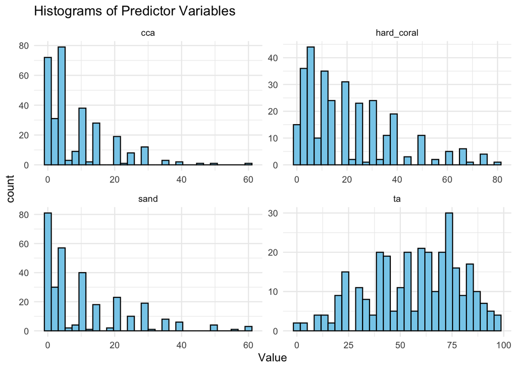

```r
#Plotting distributions
kole_predictors %>%
  gather(key = "Variable", value = "Value") %>%  # Reshape data for ggplot
  ggplot(aes(x = Value)) +
  geom_histogram(bins = 30, fill = "skyblue", color = "black") +
  facet_wrap(~ Variable, scales = "free") +  # Plot separate histograms for each variable
  theme_minimal() +
  labs(title = "Histograms of Predictor Variables")
```

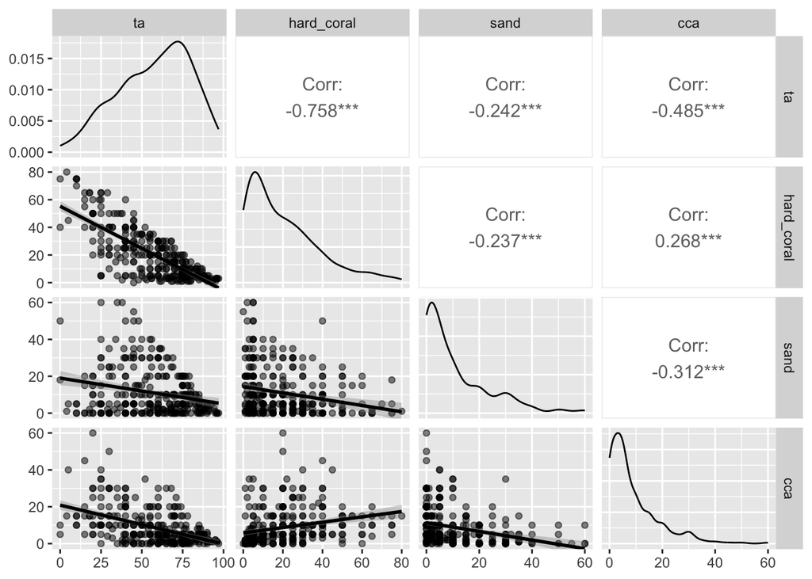

```r
# Correlation matrix visualization using ggpairs()
ggpairs(kole_predictors,
        upper = list(continuous = wrap("cor", size = 4)),  # Display Pearson correlation values
        lower = list(continuous = wrap("smooth", alpha = 0.5)), # Scatterplots with smoothing line
        diag = list(continuous = wrap("densityDiag", alpha = 0.6))) # Density plots on diagonal
```

## **Task 2**

For each of the four predictors, make single-predictor models where the response variable is kole counts. Consider which of the predictors could be transformed to reduce skew along the x-axis. For educational purposes, start by using a poisson distribution for the counts.

Quantify the degree of overdispersion in these models, and describe what it means. Based on likelihood ratio tests and effects plots, what are the relationships between kole and the four substrate types?

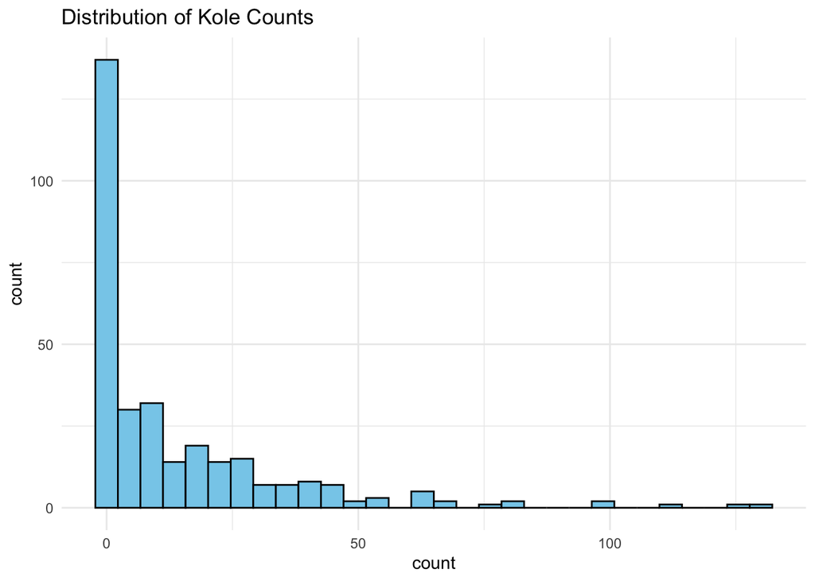

```r
# Check distribution of kole counts
ggplot(kole, aes(x = count)) +
  geom_histogram(bins = 30, fill = "skyblue", color = "black") +
  theme_minimal() +
  labs(title = "Distribution of Kole Counts")
```

```r
# Apply transformations
kole <- kole %>%
  mutate(ta_log = log(ta + 1),  # Log transformation
         sand_sqrt = sqrt(sand))  # Square root transformation

# Poisson regression models for all 4 predictors
model_ta <- glm(count ~ ta, data = kole, family = poisson)
model_hard_coral <- glm(count ~ hard_coral, data = kole, family = poisson)
model_sand <- glm(count ~ sand, data = kole, family = poisson)
model_cca <- glm(count ~ cca, data = kole, family = poisson)

# Summarizing models
summary(model_ta)
```

```
##
## Call:
## glm(formula = count ~ ta, family = poisson, data = kole)
##
## Coefficients:
##               Estimate Std. Error z value Pr(>|z|)
## (Intercept)  3.5784202  0.0352931   101.4   <2e-16 ***
## ta          -0.0177069  0.0006581   -26.9   <2e-16 ***
## ---
## Signif. codes:  0 '***' 0.001 '**' 0.01 '*' 0.05 '.' 0.1 ' ' 1
##
## (Dispersion parameter for poisson family taken to be 1)
##
##     Null deviance: 7573.1  on 309  degrees of freedom
## Residual deviance: 6862.4  on 308  degrees of freedom
## AIC: 7783.4
##
## Number of Fisher Scoring iterations: 6
```

```r
summary(model_hard_coral)
```

```
##
## Call:
## glm(formula = count ~ hard_coral, family = poisson, data = kole)
##
## Coefficients:
##              Estimate Std. Error z value Pr(>|z|)
## (Intercept) 2.0379324  0.0257021   79.29   <2e-16 ***
## hard_coral  0.0243714  0.0006953   35.05   <2e-16 ***
## ---
## Signif. codes:  0 '***' 0.001 '**' 0.01 '*' 0.05 '.' 0.1 ' ' 1
##
## (Dispersion parameter for poisson family taken to be 1)
##
##     Null deviance: 7573.1  on 309  degrees of freedom
## Residual deviance: 6481.7  on 308  degrees of freedom
## AIC: 7402.7
##
## Number of Fisher Scoring iterations: 6
```

```r
summary(model_sand)
```

```
##
## Call:
## glm(formula = count ~ sand, family = poisson, data = kole)
##
## Coefficients:
##              Estimate Std. Error z value Pr(>|z|)
## (Intercept)  2.946727   0.018964  155.39   <2e-16 ***
## sand        -0.035770   0.001685  -21.22   <2e-16 ***
## ---
## Signif. codes:  0 '***' 0.001 '**' 0.01 '*' 0.05 '.' 0.1 ' ' 1
##
## (Dispersion parameter for poisson family taken to be 1)
##
##     Null deviance: 7573.1  on 309  degrees of freedom
## Residual deviance: 6998.7  on 308  degrees of freedom
## AIC: 7919.6
##
## Number of Fisher Scoring iterations: 6
```

```r
summary(model_cca)
```

```
##
## Call:
## glm(formula = count ~ cca, family = poisson, data = kole)
##
## Coefficients:
##             Estimate Std. Error z value Pr(>|z|)
## (Intercept) 2.270516   0.021449  105.85   <2e-16 ***
## cca         0.034430   0.001153   29.85   <2e-16 ***
## ---
## Signif. codes:  0 '***' 0.001 '**' 0.01 '*' 0.05 '.' 0.1 ' ' 1
##
## (Dispersion parameter for poisson family taken to be 1)
##
##     Null deviance: 7573.1  on 309  degrees of freedom
## Residual deviance: 6846.7  on 308  degrees of freedom
## AIC: 7767.6
##
## Number of Fisher Scoring iterations: 6
```

```r
# Checking for overdispersion!
dispersion_test <- function(model) {
  sum(residuals(model, type = "pearson")^2) / df.residual(model)
}

# Compute dispersion tests for models
dispersion_test(model_ta)
```

```
## [1] 30.10215
```

```r
dispersion_test(model_hard_coral)
```

```
## [1] 28.13073
```

```r
dispersion_test(model_sand)
```

```
## [1] 30.97697
```

```r
dispersion_test(model_cca)
```

```
## [1] 30.8293
```

## **Task 3**

Now make new single-predictor models that account for overdispersion (we discussed two different ways to do this in lecture, you can do one or both).

#Fitting a negative binomial to address the overdispersion

```r
# Fiting Negative Binomial model for all 4 parameters
model_ta_nb <- glm.nb(count ~ ta, data = kole)
model_hard_coral_nb <- glm.nb(count ~ hard_coral, data = kole)
model_sand_nb <- glm.nb(count ~ sand, data = kole)
model_cca_nb <- glm.nb(count ~ cca, data = kole)

# Summarize models
summary(model_ta_nb)
```

```
##
## Call:
## glm.nb(formula = count ~ ta, data = kole, init.theta = 0.3750484251,
##     link = log)
##
## Coefficients:
##             Estimate Std. Error z value Pr(>|z|)
## (Intercept)  3.64697    0.26206   13.92  < 2e-16 ***
## ta          -0.01900    0.00427   -4.45 8.57e-06 ***
## ---
## Signif. codes:  0 '***' 0.001 '**' 0.01 '*' 0.05 '.' 0.1 ' ' 1
##
## (Dispersion parameter for Negative Binomial(0.375) family taken to be 1)
##
##     Null deviance: 365.50  on 309  degrees of freedom
## Residual deviance: 346.15  on 308  degrees of freedom
## AIC: 2085.5
##
## Number of Fisher Scoring iterations: 1
##
##
##               Theta:  0.3750
##           Std. Err.:  0.0325
##
##  2 x log-likelihood:  -2079.4990
```

```r
summary(model_hard_coral_nb)
```

```
##
## Call:
## glm.nb(formula = count ~ hard_coral, data = kole, init.theta = 0.3931303705,
##     link = log)
##
## Coefficients:
##             Estimate Std. Error z value Pr(>|z|)
## (Intercept) 1.858032   0.140369  13.237  < 2e-16 ***
## hard_coral  0.031720   0.005176   6.129 8.86e-10 ***
## ---
## Signif. codes:  0 '***' 0.001 '**' 0.01 '*' 0.05 '.' 0.1 ' ' 1
##
## (Dispersion parameter for Negative Binomial(0.3931) family taken to be 1)
##
##     Null deviance: 379.65  on 309  degrees of freedom
## Residual deviance: 346.22  on 308  degrees of freedom
## AIC: 2072.6
##
## Number of Fisher Scoring iterations: 1
##
##
##               Theta:  0.3931
##           Std. Err.:  0.0344
##
##  2 x log-likelihood:  -2066.6070
```

```r
summary(model_sand_nb)
```

```
##
## Call:
## glm.nb(formula = count ~ sand, data = kole, init.theta = 0.3729581071,
##     link = log)
##
## Coefficients:
##              Estimate Std. Error z value Pr(>|z|)
## (Intercept)  2.941783   0.124216   23.68  < 2e-16 ***
## sand        -0.035008   0.007544   -4.64 3.48e-06 ***
## ---
## Signif. codes:  0 '***' 0.001 '**' 0.01 '*' 0.05 '.' 0.1 ' ' 1
##
## (Dispersion parameter for Negative Binomial(0.373) family taken to be 1)
##
##     Null deviance: 363.85  on 309  degrees of freedom
## Residual deviance: 345.96  on 308  degrees of freedom
## AIC: 2086.9
##
## Number of Fisher Scoring iterations: 1
##
##
##               Theta:  0.3730
##           Std. Err.:  0.0323
##
##  2 x log-likelihood:  -2080.8530
```

```r
summary(model_cca_nb)
```

```
##
## Call:
## glm.nb(formula = count ~ cca, data = kole, init.theta = 0.3839858353,
##     link = log)
##
## Coefficients:
##             Estimate Std. Error z value Pr(>|z|)
## (Intercept) 1.999507   0.126584  15.796  < 2e-16 ***
## cca         0.060098   0.009659   6.222 4.91e-10 ***
## ---
## Signif. codes:  0 '***' 0.001 '**' 0.01 '*' 0.05 '.' 0.1 ' ' 1
##
## (Dispersion parameter for Negative Binomial(0.384) family taken to be 1)
##
##     Null deviance: 372.51  on 309  degrees of freedom
## Residual deviance: 345.99  on 308  degrees of freedom
## AIC: 2078.8
##
## Number of Fisher Scoring iterations: 1
##
##
##               Theta:  0.3840
##           Std. Err.:  0.0334
##
##  2 x log-likelihood:  -2072.8340
```

After fitting the Negative Binomial (NB) model to each of the single-predictor models, the results changed drastically, effectively addressing the overdispersion in the data and reducing unexplained variability. Since the Poisson model assumes variance equals the mean, the results initially showed that variance was 30 times higher than expected, making the model unsuitable. This was further confirmed by the NB model, where theta values (0.37 - 0.40) were much smaller, indicating that overdispersion was properly accounted for. While the relationship between kole presence and hard coral/CCA remained highly significant in both models, the NB model provided more accurate and reliable estimates compared to the Poisson model, reinforcing the necessity of using the NB approach for overdispersed count data.

# Comparing models and using the liklihood ratio test

```r
AIC(model_ta, model_ta_nb, model_hard_coral, model_hard_coral_nb,
    model_sand, model_sand_nb, model_cca, model_cca_nb)
```

```
##                     df      AIC
## model_ta             2 7783.383
## model_ta_nb          3 2085.499
## model_hard_coral     2 7402.686
## model_hard_coral_nb  3 2072.607
## model_sand           2 7919.648
## model_sand_nb        3 2086.853
## model_cca            2 7767.601
## model_cca_nb         3 2078.834
```

```r
lrtest(model_ta, model_ta_nb)
```

```
## Likelihood ratio test
##
## Model 1: count ~ ta
## Model 2: count ~ ta
##   #Df  LogLik Df  Chisq Pr(>Chisq)
## 1   2 -3889.7
## 2   3 -1039.7  1 5699.9  < 2.2e-16 ***
## ---
## Signif. codes:  0 '***' 0.001 '**' 0.01 '*' 0.05 '.' 0.1 ' ' 1
```

```r
lrtest(model_hard_coral, model_hard_coral_nb)
```

```
## Likelihood ratio test
##
## Model 1: count ~ hard_coral
## Model 2: count ~ hard_coral
##   #Df  LogLik Df  Chisq Pr(>Chisq)
## 1   2 -3699.3
## 2   3 -1033.3  1 5332.1  < 2.2e-16 ***
## ---
## Signif. codes:  0 '***' 0.001 '**' 0.01 '*' 0.05 '.' 0.1 ' ' 1
```

```r
lrtest(model_sand, model_sand_nb)
```

```
## Likelihood ratio test
##
## Model 1: count ~ sand
## Model 2: count ~ sand
##   #Df  LogLik Df  Chisq Pr(>Chisq)
## 1   2 -3957.8
## 2   3 -1040.4  1 5834.8  < 2.2e-16 ***
## ---
## Signif. codes:  0 '***' 0.001 '**' 0.01 '*' 0.05 '.' 0.1 ' ' 1
```

```r
lrtest(model_cca, model_cca_nb)
```

```
## Likelihood ratio test
##
## Model 1: count ~ cca
## Model 2: count ~ cca
##   #Df  LogLik Df  Chisq Pr(>Chisq)
## 1   2 -3881.8
## 2   3 -1036.4  1 5690.8  < 2.2e-16 ***
## ---
## Signif. codes:  0 '***' 0.001 '**' 0.01 '*' 0.05 '.' 0.1 ' ' 1
```

These AIC values confirm that fitting the Negative Binomial model to address overdispersion was the appropriate choice, as the values are substantially lower and closer to 0, indicating a better model fit. This is further supported by the Likelihood Ratio Test (LRT), where all Negative Binomial models outperformed the Poisson models, showing much higher Log-Likelihood (LogLik) values. Additionally, the chi-squared test results demonstrate a significantly better fit for the Negative Binomial models, with p-values all < 2.2e-16, confirming that the Poisson model was inadequate due to extreme overdispersion.

## **Task 4**

Although the single-predictor models are useful, we may get a more accurate picture of the role of each substrate type if we include all the substrate types in one model. Create such a model. Based on likelihood ratio tests and effects plots, how do the results change when all predictors are included simultaneously? Why do you think the results have changed?

```r
# Fitting the Negative Binomial model with all predictors!!
allpredict_model_nb <- glm.nb(count ~ ta + hard_coral + sand + cca, data = kole)
summary(allpredict_model_nb)
```

```
##
## Call:
## glm.nb(formula = count ~ ta + hard_coral + sand + cca, data = kole,
##     init.theta = 0.4547766048, link = log)
##
## Coefficients:
##             Estimate Std. Error z value Pr(>|z|)
## (Intercept) -2.85507    1.66061  -1.719  0.08556 .
## ta           0.04659    0.01703   2.736  0.00622 **
## hard_coral   0.07439    0.01716   4.336 1.45e-05 ***
## sand         0.01835    0.01825   1.006  0.31453
## cca          0.09260    0.02028   4.566 4.96e-06 ***
## ---
## Signif. codes:  0 '***' 0.001 '**' 0.01 '*' 0.05 '.' 0.1 ' ' 1
##
## (Dispersion parameter for Negative Binomial(0.4548) family taken to be 1)
##
##     Null deviance: 426.74  on 309  degrees of freedom
## Residual deviance: 345.03  on 305  degrees of freedom
## AIC: 2038.2
##
## Number of Fisher Scoring iterations: 1
##
##
##               Theta:  0.4548
##           Std. Err.:  0.0410
##
##  2 x log-likelihood:  -2026.2040
```

```r
# Comparing full model to single-predictor NB models
lrtest(allpredict_model_nb, model_ta_nb)
```

```
## Likelihood ratio test
##
## Model 1: count ~ ta + hard_coral + sand + cca
## Model 2: count ~ ta
##   #Df  LogLik Df  Chisq Pr(>Chisq)
## 1   6 -1013.1
## 2   3 -1039.8 -3 53.294  1.587e-11 ***
## ---
## Signif. codes:  0 '***' 0.001 '**' 0.01 '*' 0.05 '.' 0.1 ' ' 1
```

```r
lrtest(allpredict_model_nb, model_hard_coral_nb)
```

```
## Likelihood ratio test
##
## Model 1: count ~ ta + hard_coral + sand + cca
## Model 2: count ~ hard_coral
##   #Df  LogLik Df  Chisq Pr(>Chisq)
## 1   6 -1013.1
## 2   3 -1033.3 -3 40.402  8.755e-09 ***
## ---
## Signif. codes:  0 '***' 0.001 '**' 0.01 '*' 0.05 '.' 0.1 ' ' 1
```

```r
lrtest(allpredict_model_nb, model_sand_nb)
```

```
## Likelihood ratio test
##
## Model 1: count ~ ta + hard_coral + sand + cca
## Model 2: count ~ sand
##   #Df  LogLik Df  Chisq Pr(>Chisq)
## 1   6 -1013.1
## 2   3 -1040.4 -3 54.648  8.161e-12 ***
## ---
## Signif. codes:  0 '***' 0.001 '**' 0.01 '*' 0.05 '.' 0.1 ' ' 1
```

```r
lrtest(allpredict_model_nb, model_cca_nb)
```

```
## Likelihood ratio test
##
## Model 1: count ~ ta + hard_coral + sand + cca
## Model 2: count ~ cca
##   #Df  LogLik Df Chisq Pr(>Chisq)
## 1   6 -1013.1
## 2   3 -1036.4 -3 46.63  4.167e-10 ***
## ---
## Signif. codes:  0 '***' 0.001 '**' 0.01 '*' 0.05 '.' 0.1 ' ' 1
```

#Visualizing redisual plots

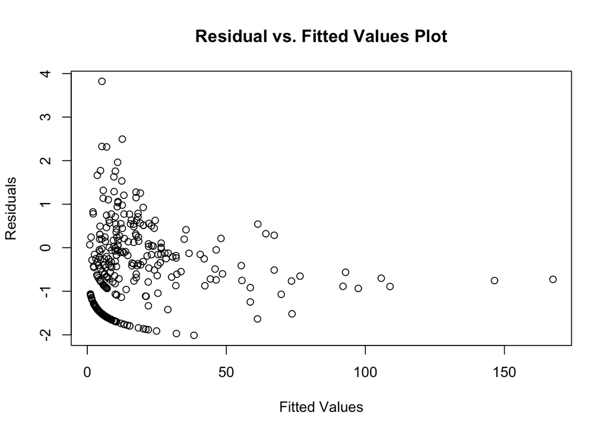

```r
plot(fitted(allpredict_model_nb), residuals(allpredict_model_nb),
     xlab = "Fitted Values", ylab = "Residuals",
     main = "Residual vs. Fitted Values Plot")
```

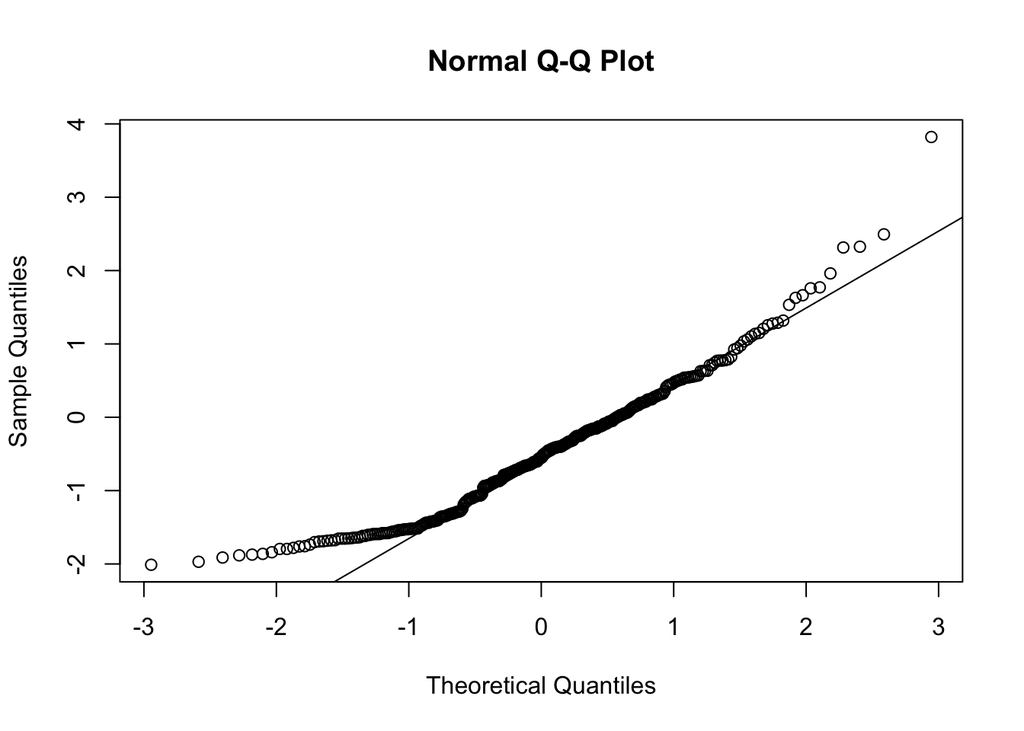

```r
qqnorm(residuals(allpredict_model_nb))
qqline(residuals(allpredict_model_nb))
```

```r
sum(residuals(allpredict_model_nb, type = "pearson")^2) / df.residual(allpredict_model_nb)
```

```
## [1] 1.512709
```

## **Task 5**

Finally, what are your overall conclusions about the substrate associations of kole,from this look at the data? Are there any additional analyses you would want to do that we have not done in this assignment?

While this study shows important insights into kole-substrate relationships, several additional questions and analyses could further refine our understanding which include whether or not kole substrate associations are similar to other herbivorous fish (e.g., parrotfish, surgeonfish) and if juveniles vs. adults prefer different substrates?